# GroupTrack — User Manual

Rel 2.7a · 2 October 2026, updated 10 October 2026 · What is new in this release

### New in 2.7a: ★ Create a Ride

**Riding together starts with a ride.** GroupTrack's community begins with the **ride package** — a route, starting at its defined trailhead, on a set date and time, with the maps it needs and its radio configuration. Send it to friends and riders who want to ride with you.

**One click, and everyone has the same preparation:** the trailhead marked on their map, the route outlined to follow, the required maps downloaded along it. At the trailhead, **check-in applies the ride's radio configuration for them.** **The fastest way to create one is a map touch:** tap a route or a track on the Ride Planning Map, then **CREATE RIDE** — Manual: Map touches, the fastest way to Create a Ride.

**No more night before the ride** spent downloading an area and hoping the trail goes where you think it does. No one asks where to meet, and no one waits at the trailhead while someone else catches up. Everyone's time goes to riding.

Tap a route — or a track you recorded — on the Ride Planning Map, tap **CREATE RIDE** (or **ADD A RIDE**), and send it. ★ Create a Ride · Sending a ride

**★ Before every ride: send the ride invite to every rider.** **Everyone on the ride needs the same ride.** Send the ride invite to **every GroupTrack rider** joining you — and make sure each one **opens it and imports it before the ride**. The ride brings the **route**, the **trailhead** and the **maps**. Without it, a rider sees carts as dots on an empty map and has nothing to follow. **It matters even with no radio:** a rider who has imported the ride can follow the route on their own tablet, and stays on course far more easily. Sending a ride

**The words used throughout:** you go on a **ride**, follow its **route**, and record your **track**. A **trailhead** is where a route starts and riders meet.

**1 About GroupTrackstart here**

**1.1 What GroupTrack is**

**GroupTrack is a trail app for off-road riders** — side-by-side, UTV, ATV, dirt bike and Jeep — and it is complete as installed. It is two products in one: a complete personal navigation product that lets you share rides and maps with other GroupTrack users, and a true situational awareness product for your group on the trail.

**On your own, it does the whole job.** The trails and the maps live **on your device**, so it keeps working where there is no signal — which is most of where you ride. Plan a route by dropping pins that snap to the trails, or let the planner build several for you to compare; mark waypoints; download the maps along the route; record where you went. (The Ride Planning Map · Letting the planner build it · The Ride Map)

**New: ★ Create a Ride.** One ride holds the route, the trailhead, the date and time, the maps to download and the mesh radio configuration. **Send it in one click; your friends open it in one click** — and ride anywhere off grid in total confidence. Friends, organizers and clubs plan for each other and all ride from the same page. (The Ride · Sending a ride, and getting one)

**Your identity.** Your rider profile — your callsign and your email — is who you are in GroupTrack: your callsign on the map and in every ride you send, your email where rides reach you. It is private: it stays on your tablet and goes only to the riders you ride with. (Your rider profile)

### Add a radio to experience full group awareness while riding

Add a **Meshtastic radio** — any Meshtastic radio — and you see your group on the map with no cell service: every cart where it is, with its callsign and role. GroupTrack sets the radio up for you. (Group Awareness)

- **Rides on the GroupTrack network — or your own.** New rides use the **GroupTrack default network**, so any rider with a GroupTrack radio can join with nothing to change. When a ride should be heard only by its riders, choose **your own network** or a **private network for that ride**. (The ride form)
- **One standard language.** Radios report in **TAK**, the format team-awareness apps use — your position with your callsign, even with the tablet in your pocket. (Setting up your radio)
- **Roles and presence.** Riders check in at the trailhead to claim a role — Leader, Middle, Tail gunner or Rider — and announce that they are there; checking in also sets the radio up for the ride. (Checking in and recording your track · Roles on the trail)

**So a ride goes like this:** tap the Ride invite — the route, trailhead and ride description are created and the maps imported; with a radio, check in at the trailhead; then **REC**. For the organizer, one step: build the ride and send it.

What is new in this release: the release notes.

**1.2 Which kind of rider are you?**

There are two ways to ride with GroupTrack, and knowing which is yours tells you what to read and what to skip.

1. **On your own.** A tablet and nothing else: trails, maps, the planner, routes, waypoints, a record of where you went — and rides you can create, send and receive. Everything except seeing your group on the map. The record button reads ⏺ REC.
2. **With a group.** You also carry a **Meshtastic radio**, so you and the riders with you see each other on the map with no cell service. You join rides, check in, and take a role; the record button reads ✔ CHK IN › REC.

**You can move between them.** Nothing has to be decided now — connect a radio in GRP Awareness and the group side appears by itself.

**Riding on your own? The parts about radios, check-in, roles and the group do not apply to you** — GRP Awareness, VIEW CART ROLES, and the radio entries in Work with Rides. Skip them with a clear conscience.

**1.3 How this goes**

You do not have to take it all on at once. Most riders never go past the second step, and that is a complete and useful app.

1. **Ride and record.** Trails on your device, maps that work with no signal, and a record of where you went. Nothing else required.
2. **Plan before you go.** Download the maps you will need, and bring in what you already have from Gaia or onX. And build the ride itself, two ways:
   - **Draw it yourself.** Drop pins along the way and GroupTrack snaps the line to the trails underneath, drawing straight only where there are none. Use this when you know where you want to go.
   - **Let the planner build it.** Give it a trailhead, how far you want to ride and any places you want to pass through, and it searches the trail network for you — then puts several routes side by side so you can compare distance, riding time and the trails each one uses. Use this when you know the area loosely, or not at all.
3. **Ride as a group.** See where everyone is, with no cell service. An organizer builds a ride and sends it; each rider opens it with one tap, checks in at the trailhead and takes a role. That can be you and a few friends on your own network, or a riding club that owns ten radios, hands them out at the trailhead and collects them afterwards.  
   **You do not need a tablet to carry a radio.** The radio reports its location by itself, so a rider only has to put one round their neck to appear on everyone else's map.

**1.4 Structure and navigation**

GroupTrack is built around **two maps**, with your radio one tap away on both. The important thing to take away is **use the right map for the task**.

1. **The Ride Map** — the map you use in the field, on the trail. Simple and focused: check in, record, and see your group.
2. **The Ride Planning Map** — built to be used online, at home. Design a route or have the planner build one, download maps for offline use, and create and share rides.

**Your radio and your rides are on both.** GRP Awareness connects your radio and shows your group's activity; Work with Rides holds your rides. There is no separate radio screen to open or hide.

**All navigation is text.** Words you tap, down the right-hand side of either map. No icons to decode. And the two maps carry the same controls in the same places — learn one and you know the other. Every control is lettered on each map's picture in its chapter.

**1.5 Map Features — the four things on your map**

Everything GroupTrack draws is one of four things. Together they are what we call the **Map Features**, and they are what the Map Features panel controls.

**Trail**

Documented ground you can ride, motorized or not. Many have no name — that does not mean they are not real, or not documented.

**Track**

A recording of where you went.

**Route**

A line you plan to ride.

**Waypoint**

A place you marked.

**1.6 Getting started**

**New to GroupTrack?** Install, then follow the Quick Start: it asks for your **rider profile** (your name, callsign and email), then loads the trails for your home state. **A radio is not needed** — maps, routes and rides all work without one. Riding with a radio? Connect it whenever you like, then set it up: **GRP Awareness → Select a ride and apply settings to the radio → GroupTrack default** (see Setting up your radio). **GroupTrack asks once, at first start:** *Do you have a mesh radio to use with GroupTrack?* — see The radio question at first start.

### Your first start, step by step

1. **Location permission** — choose **Allow all the time**, so the map keeps your position while the screen is off.
2. **Your rider profile** — your name, callsign and email, how you usually ride, your vehicle and your colour; **Save**.
3. **The radio question** — *Do you have a mesh radio to use with GroupTrack?* YES connects it in GRP Awareness; NO leaves it for later.
4. **Your home state's trails** — GroupTrack offers the state you are in; load it, or choose another.
5. **The import runs** — it takes a while; keep GroupTrack open until it finishes. Then the map opens.

[figure not shown]

1 · Location permission — Allow all the time.

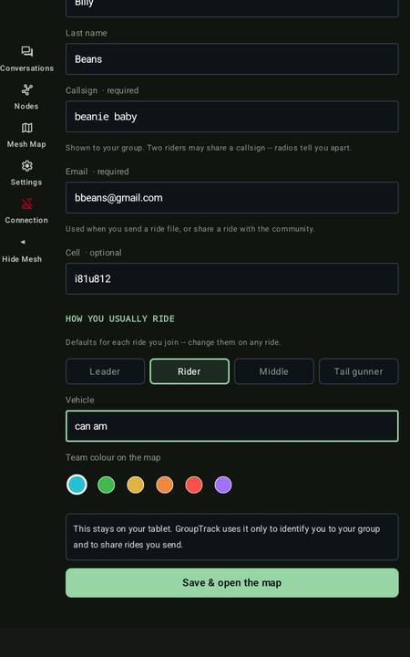

2 · Your rider profile.

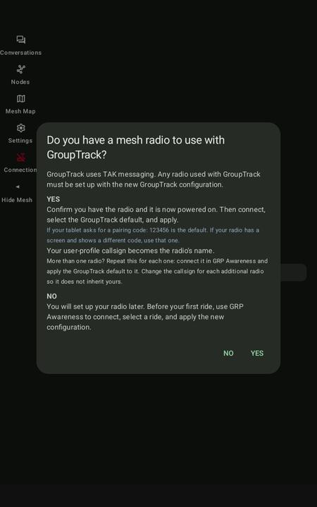

3 · The radio question.

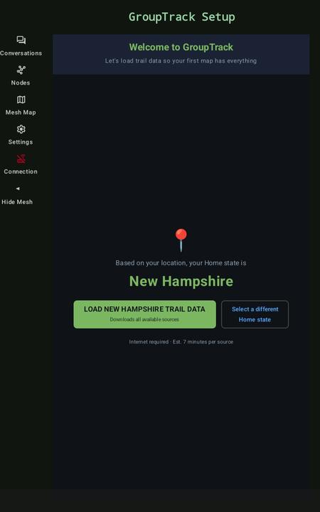

4 · Your home state's trails — load them, or select a different state.

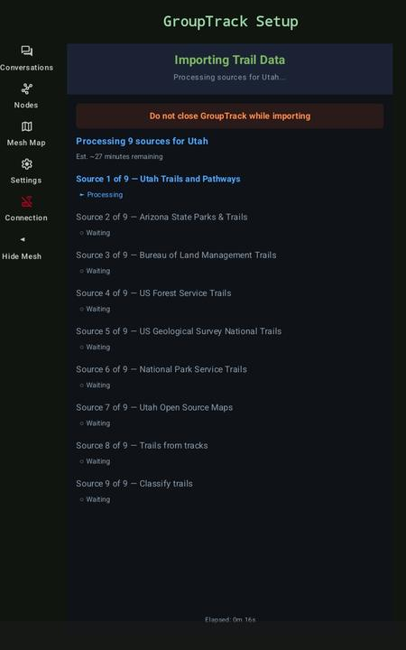

5 · Importing — do not close GroupTrack while it runs.

**Updating from 2.6?** The one-time steps — your rider profile, updating your radio once, and opening ride files with GroupTrack — and what has moved are in the release notes.

**2 Your rider profilenew — set up once**

**2.1 What it is, and why GroupTrack asks**

The first time you open this version, GroupTrack asks for your name, a callsign and an email address. It takes a minute, and you only do it once.

GroupTrack uses standard TAK messaging to put your group on each other's maps. That needs a name to show beside your cart, and an email so you can send ride details to the riders coming with you.

**Your callsign** is what everyone sees — on the map, and in every message your radio sends. Short and recognisable works best. Two riders can share a callsign; the radios still tell you apart.

**It stays on your tablet.** Nothing is sent to GroupTrack. Your details go only to the riders you ride with, over the radio, or in ride files you choose to send.

**2.2 Changing it later**

**Settings → Your Profile → Edit rider profile.** Everything is editable, though the callsign and email stay required — they are what your group and your ride files depend on.

The rest are defaults for each ride you join: how you usually ride (leader, rider, middle, tail gunner), your vehicle, and your colour on the map. You can change them on any individual ride.

**Your default role** — Leader, Rider, Middle or Tail gunner — is the role GroupTrack offers when you **check in** to a ride; most riders leave it as **Rider**. At check-in you can change it, and your callsign, **for that ride only**; your profile stays as it is. On a ride you created, **Leader** is offered instead. There is one leader per ride. (See Checking in and recording your track and Roles on the trail.)

**2.3 Riding under an organizationdrafting**

**3 The Ridewhat are its components, and what does it mean to me?**

**A ride is everything a group needs to ride together, in one package.** The organizer builds it once and sends it; each rider opens it with one tap, checks in at the trailhead, and rides.

### Create a Ride — new in 2.7a

**A ride is created from a route.** Tap any route on the planning map: a route the planner built opens its description with **CREATE RIDE**; a route you drew opens its details with **ADD A RIDE**. The ride form opens with the route, its trailhead and its picture. Map Features → ★ Create a Ride · Creating a ride from a route · from a track you recorded: Creating a ride from a track

### How a ride is built

1. **Start from a route.** A ride is always built on a route. Draw one yourself on the planning map — drop pins and it snaps to the trails (Drawing a route yourself) — or let the planner build several for you to choose from (Letting the planner build it). Every route is saved with its trailhead (Creating a route). Then tap the route on the map and **CREATE RIDE** — or **ADD A RIDE** on a route you drew yourself (Creating a ride from a route).
2. **…or from a track you recorded.** A track you recorded becomes a route — every turn kept, the track itself never changed — and the ride form opens (Creating a ride from a track).
3. **Mark the places that matter with waypoints.** A waypoint is a place you marked — the trailhead, fuel, water, a hazard, a viewpoint (A waypoint). Long press on the map to create one; it starts as a Trailhead (Long press — add a waypoint).
4. **Fill in the ride form and save.** Name, date and rollout time, public or private, the radio network, and the Leader's Notes (The ride form).
5. **Share it.** Send it as a **Ride invite**: the rider taps it, and GroupTrack creates the route, trailhead and description and imports the maps (Sending a ride, and getting one).

### The radio network — group awareness

Seeing each other on the map with no cell service needs a **Meshtastic radio** for each rider. Every ride carries its radio network — the **GroupTrack default network**, unless the organizer chose their own network or a private one for the ride. At the trailhead, checking in sets each rider's radio up for that network by itself, and from then on every radio reports its rider's position, callsign and role to the group (Setting up your radio · GRP Awareness · Checking in and recording your track).

### The components, and what they mean to you

**The ride details**

Its name, date and rollout time, the organizer, public or private, and the Leader's Notes.  
*What it means to you:* you know when and where to show up, and what to expect — straight from the organizer. The ride form

**The route**

The line the group will follow, with its description of what you will see and ride.  
*What it means to you:* you can study the ride before you go, and it is on your map the moment you open the email. Creating a route

**The trailhead**

Where the route starts — where riders meet and unload.  
*What it means to you:* no "where are we meeting?" — it is a marked point on your map. Creating a route

**Waypoints**

Fuel, water, hazards, viewpoints and other places marked along the way.  
*What it means to you:* you know what is ahead before you get there. Tapping a feature on the map

**The maps**

The satellite and topo imagery along the route — the download starts when you open the ride.  
*What it means to you:* the whole ride is on your tablet, so the map works with no signal. Sending a ride, and getting one

**The radio network**

Carried in the ride: the GroupTrack default network, the organizer's own network, or a private network for this ride.  
*What it means to you:* when you check in, your radio is set up for it by itself — you hear your group. On the organizer's own or a private network, nobody else hears the ride. Setting up your radio

**Roles**

Leader, Middle, Tail gunner and Rider — claimed when you check in, and broadcast to everyone.  
*What it means to you:* everyone knows who is leading and who is sweeping, and the map shows it. Roles on the trail

**The check-in**

At the trailhead you pick the ride and your role, and your radio is set up. Only with a radio — riding solo, there is no check-in.  
*What it means to you:* one step puts you on the ride and tells the group you are there. Checking in and recording your track

**The end of the ride**

END saves your track under the ride's name; on a public ride, rate it and choose whether to share your track.  
*What it means to you:* your ride is filed, and your rating helps the next group decide. Checking in and recording your track

**In short:** the organizer builds one ride; the rider taps it once and checks in — and has the route, the maps, the radio setup and a place in the group. The sections below take each step in order: create the route and the ride, send it, set up radios, then check in and ride.

**3.1 Creating a route**

**Every route has a trailhead — its first point.** Every route is saved **with** its trailhead, as part of the save: the route's **first point** — where you pressed REC on a track, or your first pin in Route+. If a Trailhead waypoint is already within 0.1 mile of it, that one is used; otherwise GroupTrack creates one there and asks only for its **name**. Every ride built on the route uses that trailhead. You can rename it later; to use a different spot, add a waypoint there first (long-press the map) and set its type to Trailhead.

**Saving a Route+ route with no trailhead at its first pin:** SAVE asks *"The route's first point is being created as a trailhead. Please name it"* — name it, **CREATE TRAILHEAD**, then **SAVE** again.

**With the planner.** Build a route with **Route+** on the planning map — draw it yourself or let the planner build it (see *Route+* under *The Ride Planning Map*). A route built by the planner comes with its own story: what you will see, mile by mile.

**From a track you recorded.** A track becomes a route as part of creating a ride from it — see Creating a ride from a track. The track itself is never changed.

**The route's description** is part of the route: tap the route and it opens with the first line, the distance, and your text under **ABOUT THIS ROUTE**. Riders you send a ride to see the same.

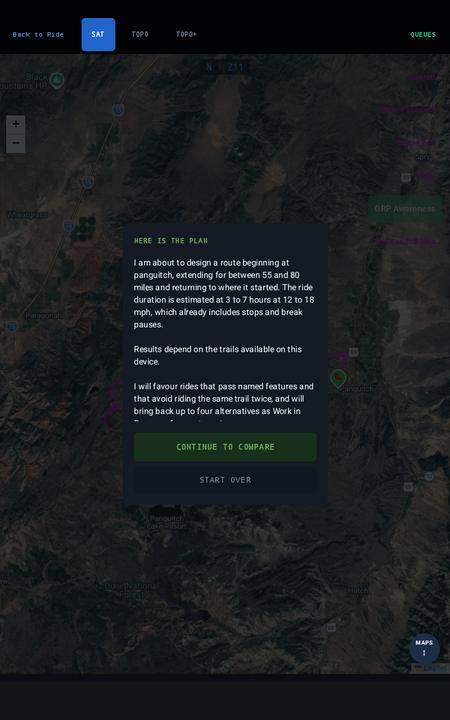

The planner's plan for the day — CONTINUE TO COMPARE, or START OVER.

**3.2 Creating a ride from a routenew in 2.7a — CREATE RIDE / ADD A RIDE**

**Where it starts:** the **planning map**. Find the route (the search box finds it by name) and tap it.

1. **The route's panel opens.** A route the planner built opens its **description**, with **ROUTE DETAILS · CREATE RIDE · DOWNLOAD MAPS** — tap **CREATE RIDE**. A route you drew yourself has no description, so it opens the **detail panel** — tap **ADD A RIDE**. (On a planner route, **ROUTE DETAILS** then **ADD A RIDE** does the same.) What each touch opens: The Ride Planning Map → Map gestures.
2. **The map fits to the route and its trailhead.** Every other layer is switched off, so the view shows only the route and where it starts; the ride's picture is taken from it. The map stays that way — turn layers back on in **Map Features**.
3. **The ride form opens** with the route, its trailhead and its picture — continue with The ride form.

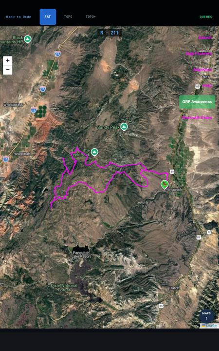

FIT — the route fills the screen.

**FIT** on a route's details shows the same view at any time.

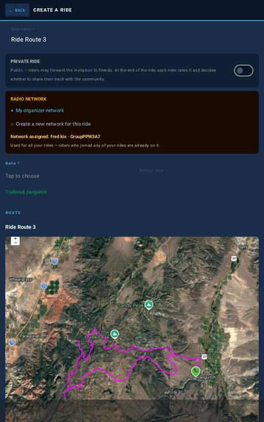

Step 3 — the ride form opens with the route and its picture.

**3.3 Creating a ride from a tracknew**

**Where it starts:** the **planning map**. Tap one of your tracks — a recording of where you went — to open its details.

1. **Tap CREATE RIDE** on the track's details.
2. **The trailhead is settled first.** A Trailhead within 0.1 mile of the track's first point (where you pressed REC) is used without asking. Otherwise a box explains: *"The trail's first point is being created as a trailhead. Please name it"* — name it and tap **CONTINUE**; the trailhead is on the map before the route is made.
3. **Name and describe the route.** A box asks for:
   - **Route name** — the track's name to start with; change it if you like. A name another route already uses is refused.
   - **Route description** — in your own words: skill level, terrain, highlights, cautions. GroupTrack writes the first line itself: *"Created from track <track> — N miles"*, measured along the track you recorded.

   The box shows *"Trailhead: <name>"*.
4. **Tap CREATE ROUTE & RIDE.** The track's line becomes the route — straights are thinned out, but **every turn is kept**, switchbacks included (within about a metre of what you rode). The route is saved **with its trailhead**. **The track itself is never changed**, and the route stays even if you cancel the ride.
5. **The map fits to the new route and its trailhead**, and the ride's picture is taken.
6. **The ride form opens** — continue with The ride form.

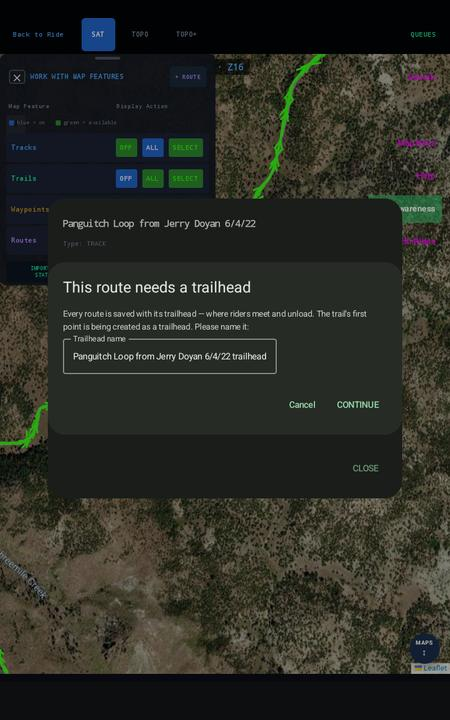

This route needs a trailhead — name the start of the track.

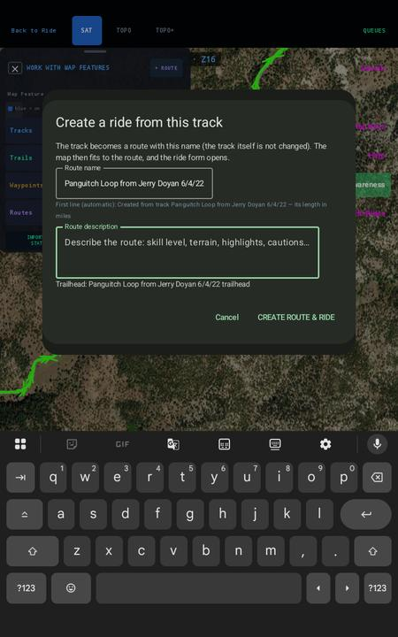

Create a ride from this track — the route's name and description.

**3.4 The ride form**

Both ways of creating a ride — from a route and from a track — end here.

**The ride's picture** is the fitted view of the route and its trailhead, taken as the form opens.

Your name and email, and the zip code (worked out from the trailhead), are recorded with the ride automatically — they are not on the form.

Tap **SAVE RIDE** — or **CANCEL** to leave the form with nothing saved.

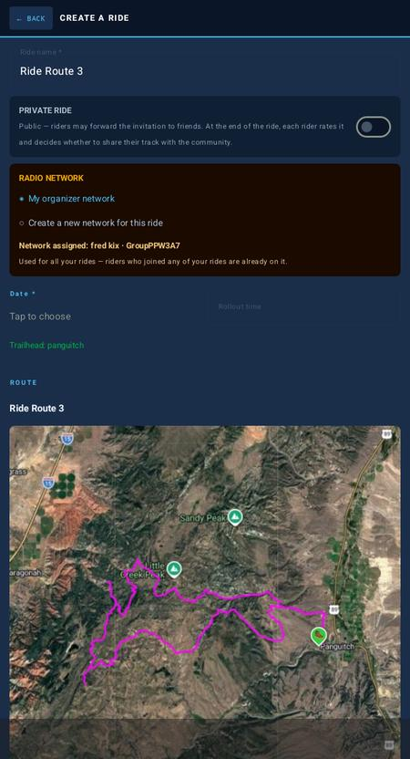

The ride form — name, private or public, and the radio network.

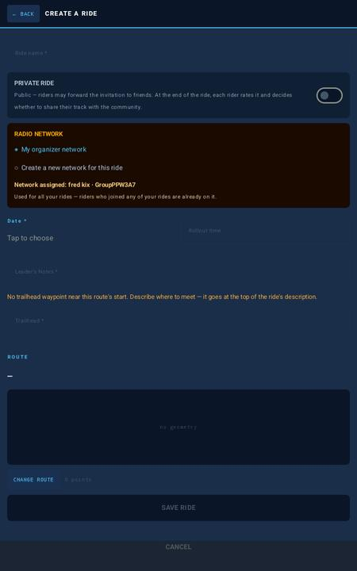

The ride form, continued — date, notes, the trailhead and the route.

**A ride's state** tells you how far along it is: **in progress** while something is missing; **completed** once it has a route, a trailhead, a date today or later and a description — only a completed ride can be sent; **sent previously** once it has gone out at least once. After a ride has been sent, **only its date can change** — to reschedule it (weather, for example); then send it again so your riders get the new date.

**The route stays with the ride.** Tap the route on the ride screen and GroupTrack explains why — your riders plan around the route you sent. To use another route, delete the ride (before sending) and add a new ride from that route. Deleting a ride never deletes the route.

**What the ride carries:** the route with its trailhead and its story, the date and description, who created it (name and email), and — for groups with radios — the ride's radio network.

**Public or private.** A ride is **public** unless you switch on **Private ride** at the top of the form. The invitation email says which: *"This is an open ride. Feel free to forward this email…"* or *"This is a private ride for the riders invited. Please don't forward this email."*

- **Public** — the invitation says riders may forward it to friends. At the end of the ride, each rider rates it and **chooses — yes or no, every time — whether to share their track** with the community. From 3.0, public rides are shown to the community through their organizer, and shared tracks help map the trails.
- **Private** — for the riders you choose; the invitation asks them not to forward it. At the end of the ride there is **no survey and no sharing**: every rider's track **stays on their own tablet**, and **no public trails are added** from it.

**The end of the ride.** See Checking in and recording your track: every recording starts with a check-in, and ends with one form — the survey and the share choice on a public ride, only the name on a private one.

**3.5 Adding a rider to your ride**

**Send them the ride** (see *Sending a ride, and getting one*). When they open it, the route, trailhead and maps arrive on their tablet.

**Their radio.** On their tablet — or on yours, with their radio connected — **Work with Rides → Apply ride to radio / Nucleus**, pick the ride, and type **their callsign** in **Callsign for this radio**. The radio joins the ride's network — the same one as yours, so you hear each other — and carries their name. Your own profile is not changed. (See *Setting up your radio*.)

**What they need first:** GroupTrack installed, and their rider profile filled in (GroupTrack asks for it the first time it opens).

**3.6 Sending a ride, and getting one**

[figure not shown]

A ride invite in your email — tap the attachment.

**Sending.** **Work with Rides → Rides**, tap the ride, then **Send**. Your email app opens with the ride attached — choose who to send it to. You can send the same ride again at any time. (**Send a ride via email** in the menu still works the same way.)

**Getting one.** Tap the email's attachment and choose **GroupTrack**, then **Always** — from then on every ride file you tap opens straight in GroupTrack. Android offers **one** GroupTrack. If ride files open somewhere else, or an earlier choice sends them to the wrong place: Android **Settings → Apps → GroupTrack → Open by default → Clear defaults**, then tap the file again.

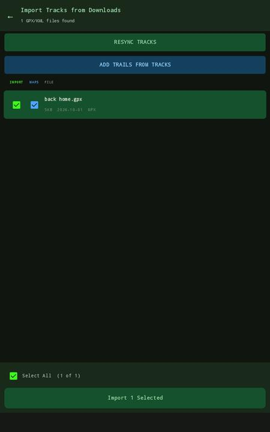

GroupTrack opens the ride's track for import.

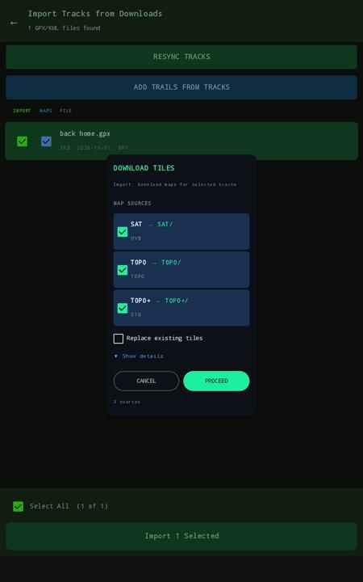

The maps the ride needs, ready to download.

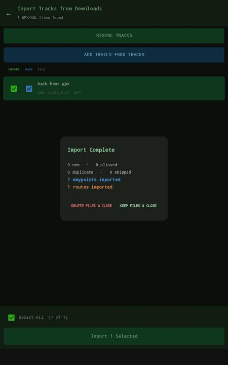

Import complete — the route and its trailhead are on your tablet.

GroupTrack keeps the ride and opens the import panel with its route already ticked — no file to find. Check which maps you want and tap **IMPORT**. **A ride file saved to your tablet** opens from **Work with Rides → Import a ride** (the file picker opens in Downloads, after a short notice — see Import a ride).

**What arrives:** the route, its trailhead waypoint, its story (tap the route to read it), and the ride's details. **The maps along the route download for you** — the download queue shows them. The ride also brings its radio network, ready for *Apply ride to radio*. The ride appears in your **Rides** list as *received from* its organiser.

**3.7 Setting up your radio**

### The radio question at first start

Next release (2.7b): turning **group awareness off** starts clean: only **your cart** stays on the map and in Select Cart — the other carts, the lead and the lead's track are cleared. Turning it back on brings the group back fresh as their radios are heard. A radio that simply disconnects while group awareness is on is different: the other carts stay where they were last seen until your radio is back. With your tablet as the source, your cart now follows **every GPS fix** as it arrives.

Next release (2.7b): the question becomes **"Will you use a Meshtastic radio to see your group on the map?"** — **YES, I HAVE A RADIO** or **NO, THIS TABLET ONLY**. **This tablet only** turns **group awareness** off: GroupTrack shows your own cart from the tablet's GPS, and the group controls (GRP Awareness, the HUD's GROUP and the GPS button) are greyed. You can change it later in **Settings → Group awareness**. If you update from 2.7a and answered NO before, group awareness starts off; otherwise on.

GroupTrack 2.7a moves to **TAK messaging**, so every radio used with it must carry the GroupTrack configuration. GroupTrack cannot tell whether you own a radio, so the first time it starts it **asks**, just before it loads your state's trails:

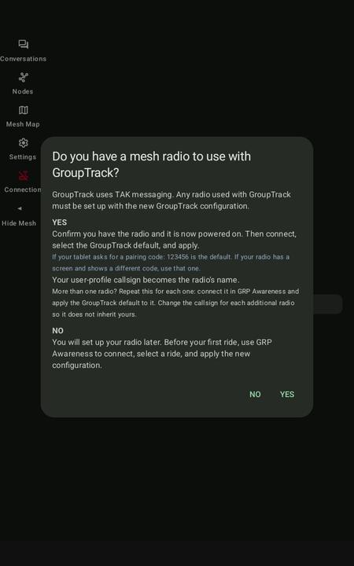

Do you have a mesh radio to use with GroupTrack? — asked once, at first start.

- **YES** — have the radio with you and switched on. GRP Awareness opens: **connect** the radio, then **SELECT A RIDE AND APPLY SETTINGS TO THE RADIO**, choose the **GroupTrack default**, and apply. If your tablet asks for a pairing code, **123456** is the default; a radio with a screen may show a different code — use that one.
- **Your callsign becomes the radio's name.** More than one radio? Repeat this for each one, and change the callsign on each additional radio so it does not inherit yours.
- **NO** — set the radio up later, before your first ride: GRP Awareness → connect → select a ride → apply.

[figure not shown]

YES opens GRP Awareness — connect your radio here.

**It asks once.** After NO, or once a radio has been set up and checked, it does not ask again. A tablet that already holds a GroupTrack radio configuration is not asked at all. The first time GroupTrack sets up a radio it keeps the radio's **original settings**, so the compare in Saved configs can show what changed.

**Experienced mesh users:** Meshtastic's own *Export configuration* (RADIO SETTINGS in GRP Awareness) saves a complete image of a radio before you change it.

**Which radios.** GroupTrack works with **any radio running Meshtastic** — handheld trackers such as the SenseCAP T1000-E, radios with a screen, base stations, and the Nucleus IP-mesh box. Connect it in GRP Awareness; checking in to a ride sets it up for that ride, or you can set it up here. Every radio is set up the same way and reports in the same standard format, so riders can mix radios on one ride.

**GRP Awareness → Select a ride and apply settings to the radio** (or **Work with Rides → Apply ride to radio / Nucleus**). Connect the radio first, in GRP Awareness. **Your own radio is set up for you when you check in** (see Checking in) — this screen is mainly for a guest's radio, or the GroupTrack default. At the top:

**Callsign for this radio** — the name this radio will carry on every map. It is there mainly for **setting up someone else's radio** — at the trailhead, a rider without GroupTrack hands you their radio: connect it, type **their** callsign here, and their radio joins the ride under their own name, not yours. For your own radio, leave it as it is — your callsign is filled in. The screen reminds you when you are setting up a radio for someone else, and your own profile is never changed. (Your callsign *for a ride* is set when you check in — see Checking in.)

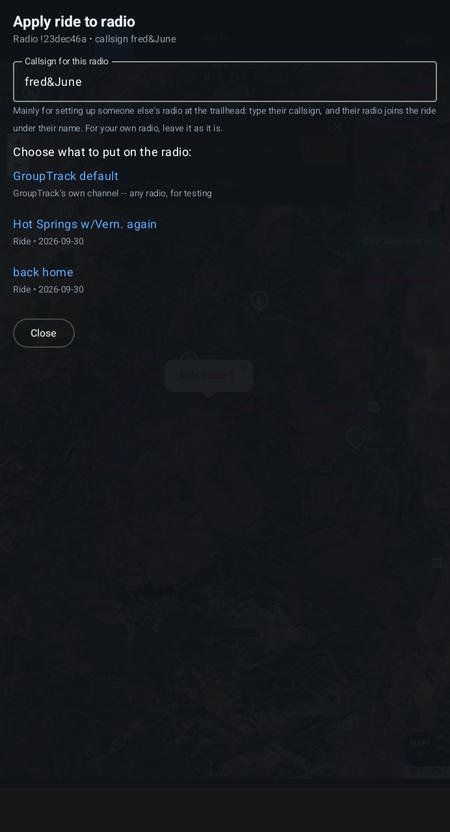

The callsign for this radio, and what to put on it — the GroupTrack default or a ride.

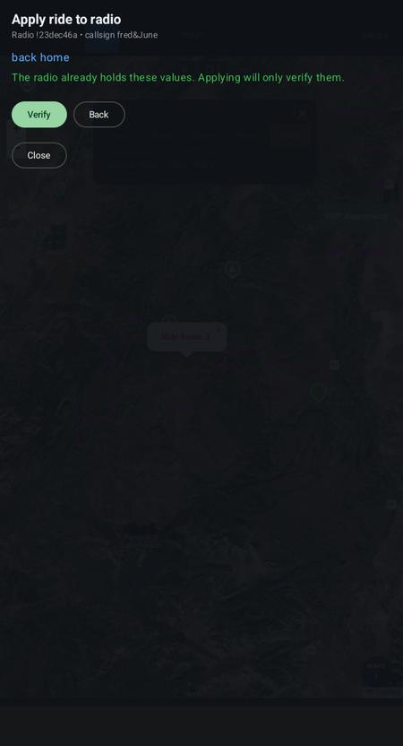

Your choice, before anything is written — Verify, then apply.

**1 · Pick what to put on the radio:** **GroupTrack default** (GroupTrack's own network — the default for new rides and for No scheduled ride, and the one-time update from 2.6) or **one of your rides**. This list shows only the default and rides; a radio's saved setups are on their own screen (below).

**2 · Check the changes.** GroupTrack lists what it will change on the radio. It only changes the settings it manages — the network, the callsign, the radio's role, its power and how often it reports — and leaves everything else as it was. Tap **Apply**.

**3 · Leave the screen open — about 3 to 4 minutes.** GroupTrack writes the settings in steps, and **the radio restarts between steps**. At the end GroupTrack waits for the radio to settle and **reconnects once more by itself**, so your tablet sees your radio straight away — you do not need to disconnect and reconnect by hand. A log shows each step.

**4 · The result.** GroupTrack reads every setting back from the radio and **ticks each one**. All ticked means the radio really holds them. Tap **Done — back to the map**. If a step could not finish, the screen says which, and why.

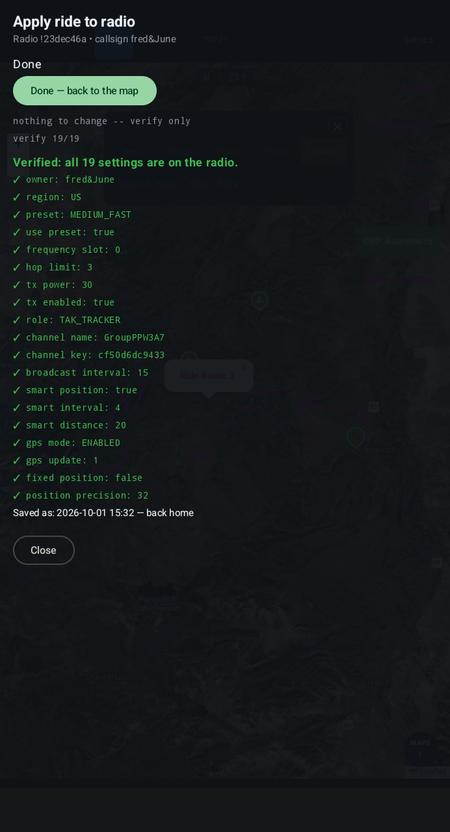

Applied — every setting checked on the radio.

**Saved setups.** The first time GroupTrack sets up a radio it saves **how it found it** ("As found"); after every setup it saves the result, **named after the ride** — and after the rider, when you set up someone else's radio. Each radio has its own saves. **Review / apply saved configs** lists them, with **Radio now** — what the radio holds at this moment — at the top:

- **Apply** — tap a saved setup, then **Apply**: the same steps as above, straight to its list of changes. This is how you put a radio back.
- **Compare** — tap one, then **Compare with…**, then tap another: every difference between them, **managed** settings first (what an apply would change), then **everything else**, for information. Comparing never changes the radio.
- **Close** returns you to where you were.

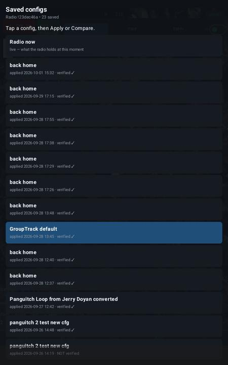

Saved configs — every apply is kept; tap one to compare.

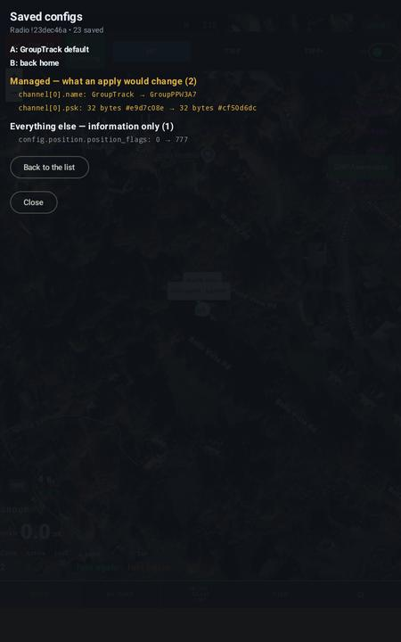

What differs between two saved configs.

⚠ **Set your radio up with GroupTrack, not by hand.** Android's radio settings offer only minutes and hours; a radio set by hand can report far more often than it needs to and crowd the channel for everyone.

**3.7.1 The GroupTrack default, setting by settingto check a radio, or finish a setup by hand**

These are the values GroupTrack writes when it sets a radio up — any Meshtastic radio. They are listed in the order the setup writes them. Use this page to compare a radio with one GroupTrack set up, or to finish by hand a setup that stopped part-way. **GroupTrack writes only these settings**; everything else on the radio (display, telemetry, other modules) stays as the radio has it.

**If the setup stops,** it tells you at which group. Everything before that group was written; nothing after it. Run the setup again, or set the remaining groups below by hand.

#### 1 · Owner

| Long name | your callsign | From your rider profile, or the guest's callsign. |
| --- | --- | --- |

#### 2 · Device, LoRa and Position (one change — the radio restarts)

[output not shown]

#### 3 · Channel

| Name | GroupTrack | The GroupTrack network. |
| --- | --- | --- |
| Key | set by GroupTrack | Applying the GroupTrack default (or a ride) writes the key. It is not printed here — anyone holding it can see your group. |
| Position precision | 32 | Full GPS precision. |

#### 4 · Modules

| Serial | on | Only the on switch — leave its other settings as they are. |
| --- | --- | --- |

#### 5 · Bluetooth (always last)

| Bluetooth | on |  |
| --- | --- | --- |
| Pairing mode | No PIN | After this change, forget the radio in Android's Bluetooth settings and pair it again if it will not reconnect. |

⚠ Even so, **let GroupTrack set the radio up** whenever it can — it writes each group, waits for the radio to restart, then reads every setting back and checks it.

**3.8 Checking in and recording your tracknew**

**Check-in is for group awareness only.** It needs a connected radio. Riding solo with a tablet alone, you never see these screens: the button reads **⏺ REC** and records straight away.

**Everybody checks in first thing at the trailhead.** Radio on, GroupTrack started, check in. **Checking in is what puts your radio on the ride's network** — until then it cannot hear the group. The **Leader, Middle and Tail gunner check in among the first**, so the whole group learns their roles; the ride starts once everyone has checked in.

**Check in first.** With your radio connected, the red record button on the ride map reads **✔ CHK IN › REC**: you cannot record until you have checked in. **No radio connected?** Then it reads **⏺ REC** — a solo ride: tap it and GroupTrack records straight away, no check-in. It switches by itself as your radio connects or drops. Tap **✔ CHK IN › REC**:

- **Which ride?** Every ride on your tablet that has not been removed, **newest first**, opened at **today** — scroll up for upcoming rides, down for past ones (a rescheduled ride is there too). **All** or one organizer's rides, from the buttons above the list. If exactly one is dated today, it is already chosen. Pick **No scheduled ride** for a recording that is not part of a ride. With **No scheduled ride**, CHECK IN first puts your radio back on the **GroupTrack default network** — after a ride on a private network, your radio returns to the network every GroupTrack rider shares. Tick **Keep my radio as it is** to leave it alone.
- **Callsign for this ride** — yours to start with; change it for this ride only (a shared cart, a guest driver). Your profile is not changed.
- **Role** — Leader, Rider, Middle or Tail gunner, always asked (with *No scheduled ride* too); your profile's default to start with, and **Leader** when it is your own ride. **There is one Leader, one Middle and one Tail gunner:** if another rider already holds the role you choose, a **red window** says who holds it, and you choose another.
- **Your radio** — GroupTrack compares it with the ride: *"Radio ready for this ride"*, or it will be set up when you check in.

Tap **CHECK IN**. **If your radio is not on the ride's network yet, CHECK IN sets it up first** — the same steps as Setting up your radio, about a minute, with its progress on screen — then checks you in. The setup runs once, start to finish. If it cannot finish, the check-in reopens with your choices kept. Checking in does not start recording: the button now reads **⏺ REC** — tap it when the group rolls out.

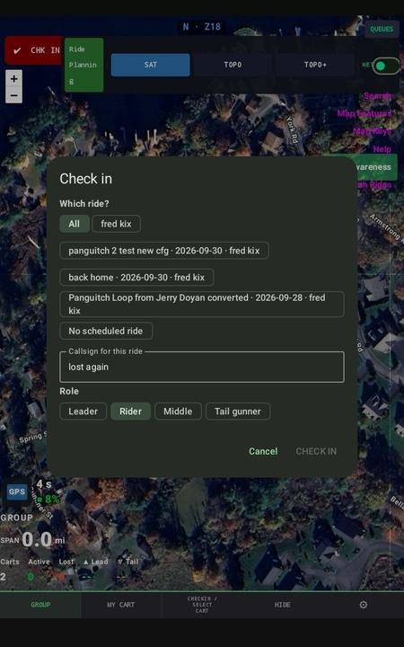

Check in — the ride, your callsign and your role.

**At the end, tap END.** One form saves your ride:

- **A ride:** the track is **named after the ride** — every rider's recording of it carries the same name, and it cannot be changed.
  - **A public ride** — rate it (1–5 stars), its difficulty (easy, moderate, hard), whether you would recommend it, notes if you like, and **Share this ride's track with the community?** — **Yes or No, every time**; there is no default. **SAVE** becomes available once they are done; a line under the form says what is still missing.
  - **A private ride** — no survey and no sharing: your track stays on your tablet.
- **No scheduled ride:** you name the track; no survey, no sharing.

Your survey belongs to the ride — one per rider per ride; saving again replaces it. The track is yours: only you decide whether it is shared. **DELETE** still asks before throwing a recording away. After saving, the button reads **✔ CHK IN › REC** again: each recording starts with its own check-in.

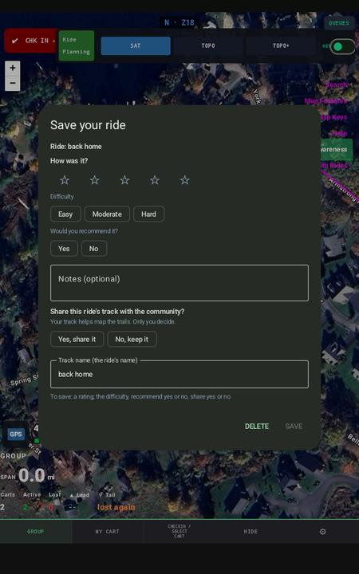

Save your ride — the form at END.

**3.9 Radio range and group sizenew**

**A quieter channel.** GroupTrack's radios use the **MEDIUM_FAST** setting, and report every 30 seconds standing and, moving, every 100 metres — at most every 6 seconds. Measured with two radios at the earlier, busier values (15 s / 4 s), the share of airtime they use fell from about 22% to 4–5% — so many more riders fit on one ride before the channel gets crowded.

**The trade-off is range.** On a T1000-E, plan on about **¾ mile between riders** in open country; terrain and trees shorten it, a clear line of sight lengthens it. Radios with a bigger antenna or more power reach further. *These are estimates, to be measured on real trails.*

**Radios relay for each other.** A rider out of direct reach is still heard through the riders between you, so a strung-out group stays connected as long as **no gap between riders is longer than a radio's reach**.

**Strong radios make a backbone.** A radio with a good antenna — 1 watt, mounted high on the vehicle — reaches much further, and hears weak radios better too. Put strong radios **at the lead, at the tail, and in the middle of a long group**. The leader's radio matters most: it carries the leader's track to everyone behind.

**Every radio on a ride must use the same setting.** GroupTrack sets this for you when you apply the ride; radios set differently cannot hear each other at all.

**3.10 Roles on the trail**

**Your role is chosen when you check in** — Leader, Rider, Middle or Tail gunner — for that ride only (see Checking in). There is **one leader** per ride.

**Everyone is a Rider unless they check in as the Leader, Middle or Tail gunner.** When those three check in, **their tablets tell the group** — over the radio, for a few minutes into the ride — so every cart learns who holds each role. Nothing is set on the radios themselves.

**What you see:** every cart's callsign and role beside it on the map and in **VIEW CART ROLES**; **the lead and tail markers follow the riders who hold those roles**. When the Leader is known, **REC does not ask you to choose the lead cart**.

**Roles stay put for the ride** — a cart that drops out of range keeps its role. They end with the ride.

**One of each.** A ride has one Leader, one Middle and one Tail gunner at most; any number of Riders. **The Leader is the key role** — the Leader's cart is the lead cart. With no Tail gunner, the last cart is the tail.

**Each rider sets only their own role.** Nobody can give a role to someone else, and a role someone already holds can't be taken until it is released.

**Changing roles at a stop:** open **VIEW CART ROLES** and tap your own cart in the list (**Change my role**). Choosing **Rider** releases your role. **One rider at a time**, and **the Leader changes last** — for example, to hand over the lead: the Leader changes to Rider, then the new Leader takes Leader. Every tablet follows within seconds.

**The lead cart:** when REC is pressed with no Leader known, GroupTrack asks you which cart leads — on your tablet only. As soon as a Leader is heard, the lead moves to them. This works on every ride, scheduled or not.

Next release (2.7b): **The rules for roles and the lead, in one place:**

- **Roles show only while you are checked in.** Before check-in, and after END, the carts show without roles.
- **The Leader is the lead — on every tablet.** When a rider checks in as Leader, every tablet makes that cart the lead.
- **No Leader, no lead.** When the Leader changes to Rider, the lead is cleared on every tablet. A rider claims Leader in VIEW CART ROLES, or REC asks which cart leads.
- **Two claims of one role — both go back to Rider.** If two riders claim Leader, Middle or Tail gunner at the same moment, both are set back to Rider. Each tablet shows a **flashing red ROLE CONFLICT** message — *"You and … both claimed Leader. Only one rider can hold Leader, so BOTH of you have been set back to Rider. Agree who takes Leader, then that rider claims it again in View Cart Roles (open behind this message). A role can be claimed once nobody else holds it."* — with VIEW CART ROLES open behind it. Tap **OK**, agree, and one of you claims the role again.
- **Why both?** The two tablets cannot tell whose claim came first, so neither keeps it — the riders decide.

**3.11 Moved to the Ride MapWork with Rides, GRP Awareness, GPS**

These now sit with the control that opens them: Work with Rides (5.18), GRP Awareness (5.10) and GPS (5.17).

**4 The Ride Planning Mapwhere you build rides before you go**

Built to be used online, at home. This is where the work happens before you go — getting the trail data, building the ride, and downloading the ground it crosses.

Every control is lettered on the picture below. Tap a letter, or its heading in the list, to go straight to it.

[figure not shown]

Ride Planning Map — every control lettered; tap a letter to go to it

1. A**Back to Ride** — returns to the Ride Map 4.1
2. B**SAT** — the map underneath 4.2
3. C**TOPO** — the map underneath 4.2
4. D**TOPO+** — the map underneath 4.2
5. E**QUEUES** — downloads in the background 4.3
6. F**Search** — reposition the map, by name 4.4
7. G**Map Features** — features, imports, and Route+ 4.5
8. H**Map Keys** — what the lines mean 4.6
9. I**Help** — the three documents 4.7
10. J**GRP Awareness** — your radio in one place 4.8
11. K**MAPS** — imagery for offline use 4.9
12. L**Zoom + / −** — in and out — or pinch 4.10
13. M**Tapping a feature on the map** — trails, tracks, routes and waypoints open their details 4.11
14. N**Work with Rides** — rides — share, edit, delete; import; apply to your radio 4.12
15. O**Long press — add a waypoint** — the new waypoint starts as a Trailhead 4.13

**4.1 A · Back to Ridereturns to the field map**

Returns to the Ride Map — the one you use on the trail.

**4.2 B, C, D · SAT, TOPO and TOPO+the map underneath**

Three slots, each holding a map source you chose. Tap one and the map redraws in that source. What is drawn on top does not change.

[figure not shown]

SAT.

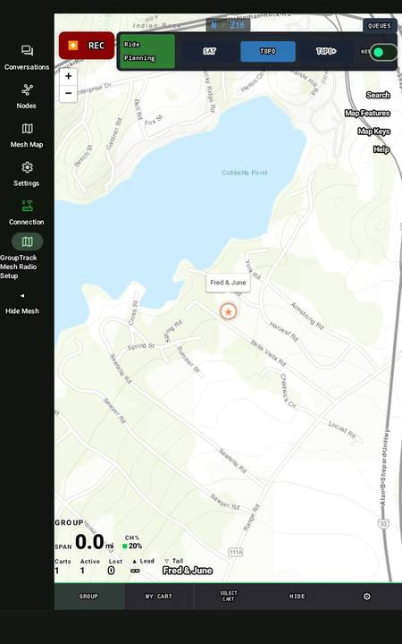

TOPO.

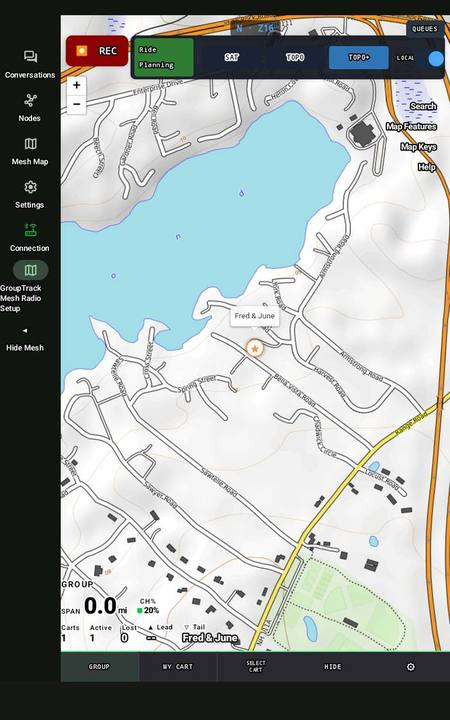

TOPO+.

Which source sits in which slot is yours to choose, in Settings. Out of the box, **TOPO+ holds OpenTopoMap**.

**4.3 E · QUEUESdownloads in the background**

Map downloads run in the background so they do not tie up the screen.

[figure not shown]

Running.

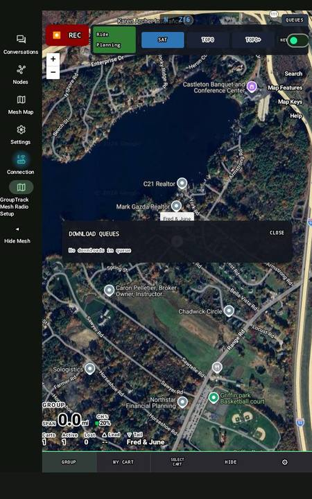

Nothing queued.

Leave the screen and carry on — the download continues. **If the device is turned off it picks up where it stopped** rather than starting again.

### Managing the queue

- A job can be **held**, **cancelled**, or **purged** once complete.
- Anything waiting can be **promoted to run next**.

### What runs first

The queue sorts itself so the work you need soonest happens soonest.

1. **Tile deletions** — freeing space before filling it.
2. **Anything you promoted.**
3. **Corridor downloads** — a route's tiles.
4. **Area downloads** — a bounding box.
5. **Map source refreshes** — last, and they wait.

**A large refresh never blocks you.** Ask for an area or a corridor while one is running and yours goes ahead of it; the big job carries on afterwards.

There is a limit on how many downloads run at once. It is already tuned — worth leaving alone.

**4.4 F · Searchreposition the map, by name**

Search repositions the map so what you searched for is **centred**. It is what lets you plan a ride anywhere in the country from your living room.

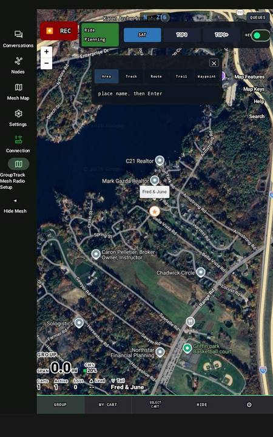

The search bar.

### Finding one of your own

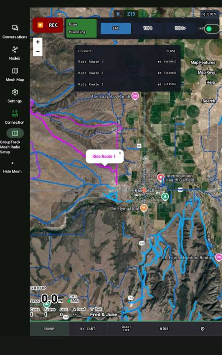

Matches.

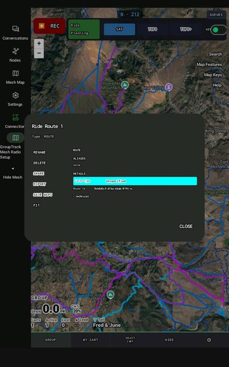

Tap the name you want.

Searching for a track, route or waypoint produces a list. Tap the name of the one you want and the map moves to it.

### Finding a place

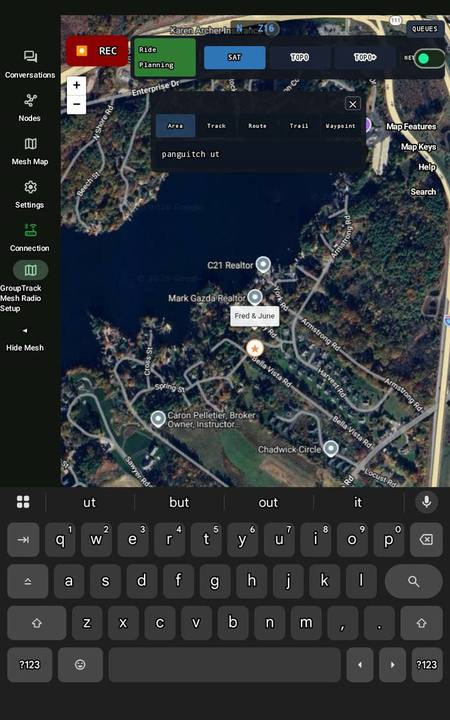

Type a place name.

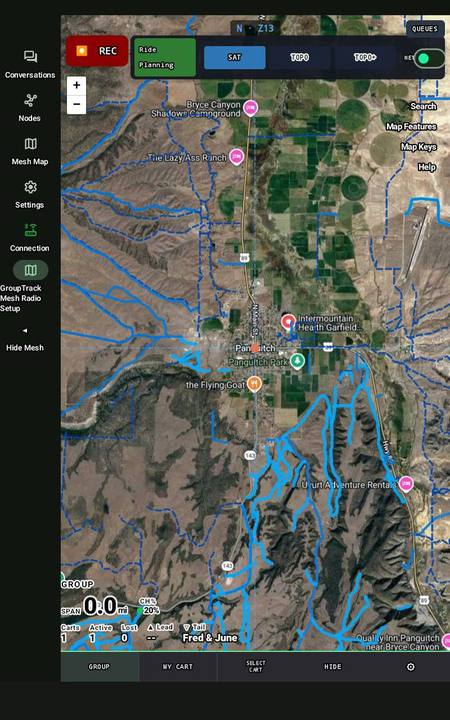

The map moves there.

**Qualify the name with its state** — "Panguitch UT". The same name exists in many states, and landing in the wrong one is not obvious: the map moves, trails draw, and everything looks right.

**Area search needs an internet connection.** Everything else — your tracks, trails, routes and waypoints — searches off grid.

**4.5 G · Map Features★ create a ride · routes, tracks, trails, waypoints · display · imports · Route+**

**Everything you can do with a route, a track, a trail or a waypoint starts with one tap.** Tap it on the map, or find it with Map Features → SELECT, and its panel opens — a route the planner built opens its **description** when tapped, its detail panel from SELECT. **Routes and tracks are where rides are created** (★ Create a Ride, new in 2.7a); trails and waypoints have their own functions.

- **A route** → 4.5.2 Routes — ★ Create a Ride
- **A track** → 4.5.3 Tracks — ★ Create a Ride
- **A trail** → 4.5.4 Trails
- **A waypoint** → 4.5.5 Waypoints

Map Features also controls how the features are displayed, so you can put your focus on what you are working on and take away the clutter around it.

The same four feature types as on the Ride Map, with the same OFF, ALL and SELECT — and three things you cannot do in the field: **importing trail data**, **importing from other apps**, and **Route+**.

[figure not shown]

Trails and tracks together.

**4.5.1 ★ Create a Ridenew in 2.7a — from a route, or from a track you recorded**

**This is the only place rides are made: tap a route or a track on the Ride Planning Map.** A ride is always built on a route — one you drew, one the planner built, or one made from a track you recorded. Tap it, tap the ride button, and the ride form opens with the route, its trailhead and its picture. Then save it and send it. (On the Ride Map the same tap opens the details with no ride button.)

### Create a ride from a route

**Requires:** a saved route — Route+ builds one.

1. **Tap the route** on the Ride Planning Map. Can't see it? **Map Features → Routes → SELECT** shows just that route, or search for it by name.
2. **A route the planner built** opens its description — tap **CREATE RIDE**. **A route you drew** opens its details — tap **ADD A RIDE**.
3. **The map fits to the route and its trailhead**, and the ride's picture is taken.
4. **The ride form opens** — fill it in and save (The ride form), then share it (Sending a ride).

[figure not shown]

Finding the route: Map Features → Routes → SELECT.

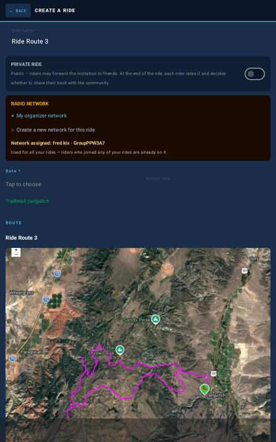

The ride form opens with the route.

### Create a ride from a track you recorded

**Requires:** a track you recorded or imported.

1. **Tap the track** on the Ride Planning Map. Can't see it? **Map Features → Tracks → SELECT**.
2. On its details, tap **CREATE RIDE**.
3. **Name the trailhead** if there is none within 0.1 mile of the track's start.
4. **Name and describe the route**, then **CREATE ROUTE & RIDE** — the track becomes a route, every turn kept; the track itself is never changed.
5. **The ride form opens** — fill it in and save.

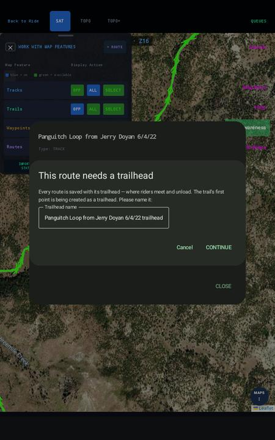

Name the trailhead.

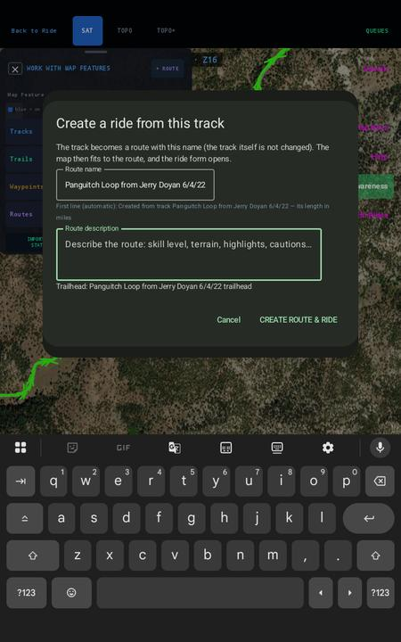

Name and describe the route — CREATE ROUTE & RIDE.

The full walk-through, step by step: 3.2 Creating a ride from a route · 3.3 Creating a ride from a track.

**4.5.2 Routesdescription, details · ★ create a ride**

Tap a route — on the map, or SELECT it in Map Features. **What opens depends on how the route was made:**

- **A route the planner built** opens its **description** — the planner's story of the route — with **ROUTE DETAILS · CREATE RIDE · DOWNLOAD MAPS**.
- **A route you drew** (or tap ROUTE DETAILS) opens its **detail panel**: **RENAME · DELETE · SHARE · EXPORT · OVERVIEW · ADD A RIDE · BUILD ROUTES FROM RECIPE · SAVE MAPS · FIT**.

**CREATE RIDE / ADD A RIDE**

★ Make this route a ride — Create a Ride.

**SAVE MAPS / DOWNLOAD MAPS**

Download the map corridor along the route — Along a route.

**OVERVIEW**

The route's description, for a planner route.

**BUILD ROUTES FROM RECIPE**

**SHARE / EXPORT**

Send the route as a GPX file, or save it to Downloads.

**RENAME · DELETE · FIT**

Rename it, delete it, or fit the map to it.

**4.5.3 Tracksdetails · ★ create a ride**

A **track** is a recording — where you actually went. Tap one, or SELECT it in Map Features, and its detail panel opens: **RENAME · DELETE · SHARE · EXPORT · CREATE RIDE · SAVE MAPS · FIT**, with its distance, duration, speed and source.

**CREATE RIDE**

★ Turn the track into a route and a ride — Create a Ride. The track itself is never changed.

**SAVE MAPS**

Download the map corridor along the track.

**SHARE / EXPORT**

Send the track as a GPX file, or save it to Downloads.

**RENAME · DELETE · FIT**

Rename it, delete it, or fit the map to it.

**4.5.4 Trailswhat is known about it**

Tap a trail, or SELECT trails by category in Map Features, and its detail panel opens with what is known about it: its type (the Map Keys category), source, land status and use. Functions: **SHARE · EXPORT · FIT**. Trails come from the map data, so they cannot be renamed or deleted — except **rider trails**, which you made from your own tracks.

[figure not shown]

A trail's detail panel — here an unclassified (Shape only) trail.

**4.5.5 Waypointsa place you marked**

Tap a waypoint — on either map — and its detail panel opens: **RENAME · DELETE · CHANGE TYPE · FIT**. To make one, long-press open map (Long press — add a waypoint). Details below.

**4.5.5.1 Waypoint details — tap a waypointnew in 2.7a**

[figure not shown]

A waypoint's detail panel.

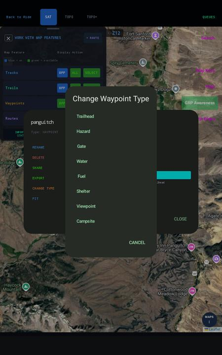

**4.5.6 Controlling how map features are displayedfocus, and removing clutter**

[figure not shown]

Tracks on.

[figure not shown]

SELECT on tracks — combinations, and the name for details.

[figure not shown]

SELECT on trails — by category.

Press a track's name in the selection list to see its details.

[figure not shown]

Track details.

[figure not shown]

The map keys — tap a row to customise.

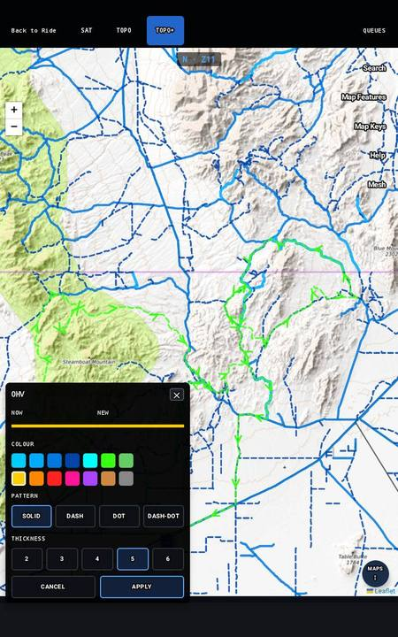

Colour, pattern and thickness.

**4.5.7 Importing trail datastate or area**

Trail data is what everything else depends on. Import it for a whole state, or for an area.

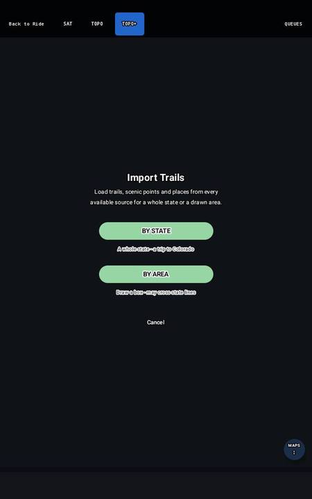

By state, or by area.

### By state

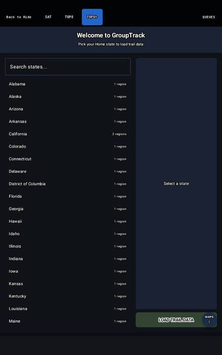

Pick your state and load the trail data.

Search or scroll to your state and press **LOAD TRAIL DATA**. It takes about twenty minutes and pulls from every public source covering that state.

Use wifi, not mobile data — this is a large download. And import **every state you ride in**, including ones you only cross into. A ride that leaves your loaded states has no trail data underneath it.

### By area

[figure not shown]

By area.

[figure not shown]

Smaller and faster when you only need one part of a state.

**4.5.8 Importing from Gaia or onXGPX from other apps**

Tracks, routes and waypoints you have collected in other apps come across as GPX files.

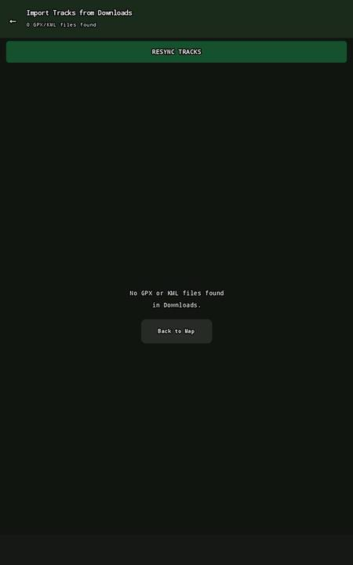

What GroupTrack found in Downloads.

1. **Export** from Gaia or onX. If you do it on this device the file lands in Downloads and GroupTrack finds it.
2. Exported somewhere else? Get the file into the Android **Downloads** directory however suits — email, a website, cloud storage.
3. Choose what to import.

There is no direct connection between the apps. It is export, then import, and the file passes through Downloads on the way.

### Sharing a route with another rider

Export a route and the file carries more than its shape. The **narrative** travels with it — the summary, what you will see, the cautions — and so does the **recipe**, the settings it was built from.

That means the rider you send it to can open **BUILD FROM RECIPE** and search again on their own device. **They may get different routes than you did**, and that is the point: the recipe is a set of instructions, not a copy of your answer. Their trail data is not yours.

Opened in Gaia or onX, the route still reads normally — those apps see the name, the description and the points, and ignore the rest.

### Why you should import all of them

Importing your old tracks is worth more than keeping a record of where you have been. **Where one of your tracks crosses ground that no published map covers, GroupTrack adds that stretch to your trails as an unnamed trail.**

Published trail data misses a great deal. Roads and tracks that riders use every weekend are simply not in it. Your own rides are proof that ground is rideable — you rode it — and that is better evidence than any survey offers.

So every track you bring in makes the map more complete, and **the route planner is only as good as the network underneath it**. A planner working from published trails alone will route you the long way around ground you know perfectly well.

**Load your states first.** A ride that crosses into a state you have not imported has no trails underneath it, so the whole stretch is treated as new ground — even where trails already exist there. Import the states you ride in, then import your tracks.

After that the order does not matter. Each track is checked as it arrives, so you can import them whenever you like and there is nothing to run afterwards.

**To select several files at once,** press and hold the first file, then tap the others.

### Removing one

Tap a rider trail and you get a **DELETE** button. Surveyed trails do not have one — deleting those achieves nothing, because the next trail reload brings them straight back from the catalogue.

A rider trail comes back too, if the track that made it is still on the device and trails are cleared and reloaded. To be rid of one for good, delete the track as well.

The commonest reason to remove one: a recorder left running on the drive to the trailhead. Highways are not in the trail data, so the whole drive reads as new ground and gets added.

### What each category means

Open **Map Keys** and press **CATEGORIES EXPLAINED** at the foot of the panel. Every line on the map is one of these:

- **OHV** — posted trails for ATV/OHV use only.
- **Track** — two wheel tracks, farm, forest or open country.
- **Forestry / access** — access unless posted otherwise. Look for a sign.
- **Shape only** — shape and route of reported trails that are otherwise unclassified. Somebody drew the line; nobody said what it is — check the satellite imagery before you plan on it.
- **Rider trails** — ridden on a recorded track, so UTV accessible. This is ground you have been on, which is the strongest thing the map knows.
- **Unofficial / uncertain** — not available for riding.
- **Hiking & biking**, **Hiking**, **Biking**, **Equestrian**, **Steps / bridge** — non-motorized. Off by default; switch them on in Map Features if you want to see them.
- **My tracks** and **My routes** — your own recordings and plans.

Tap any name in the key panel to change its colour, line pattern or thickness. Those choices are yours and stay on your device.

### What these trails look like

They are **unnamed**, and they carry their own colour so you can tell them from surveyed trails at a glance. They are filtered and displayed like any other trail.

They are honest rather than perfect: a rider trail says you rode that ground, not that it is a maintained road or that anyone else may use it. Check ownership and access the same way you would anywhere else.

**Routes you built before will come back different.** Once there is more network to work with, the planner finds rides it could not find before. That is the improvement working, not a fault.

**4.5.9 Route+build a route to follow**

Route+ builds a route to follow. Two ways: **draw it yourself**, or **let the planner build several and compare them**.

**A ride is created from a route.** Tap any route on the planning map: a route the planner built opens its description with **CREATE RIDE**; a route you drew opens its details with **ADD A RIDE**. The ride form opens with the route, its trailhead and its picture. Map Features → ★ Create a Ride · Creating a ride from a route · from a track you recorded: Creating a ride from a track

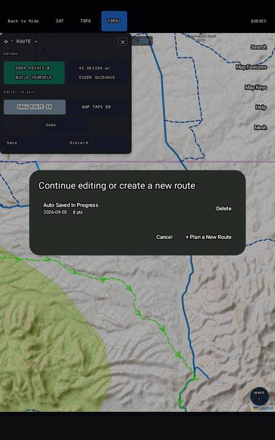

Anything unfinished is offered first.

If you left a route half-built, it is offered here — continue it, or start something new.

**4.5.9.1 Drawing a route yourselfdrop pins, it snaps to trails**

Use this when you know where you want to go.

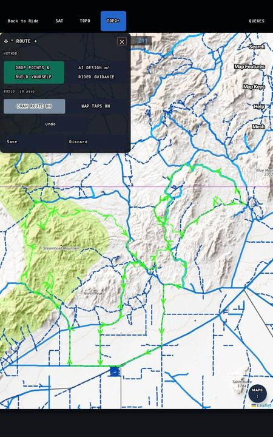

Dropping pins.

Drop a pin at each point along the way. **Where there are trails underneath, the line snaps to them.** Where there are none, it draws straight between your points.

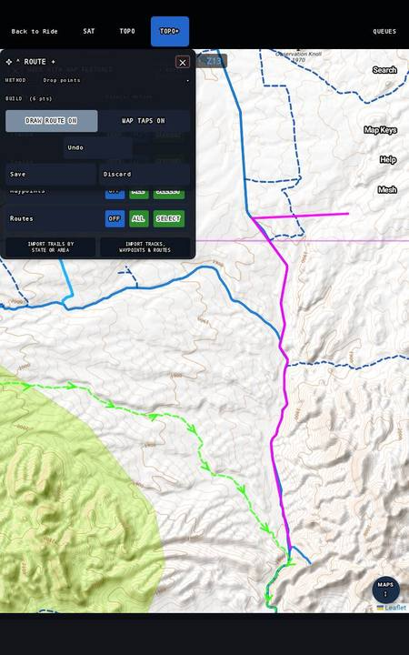

Saving as you go.

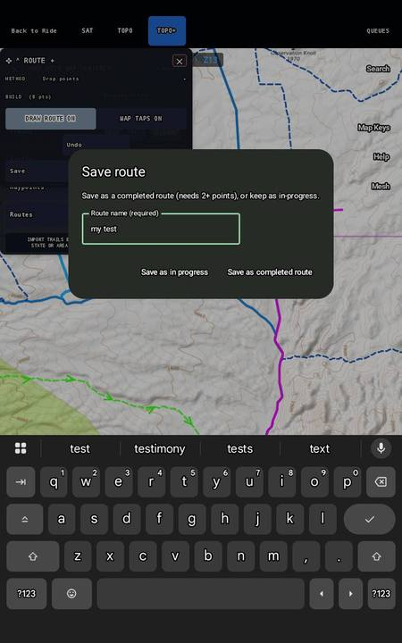

Finished, or still in progress.

A route can be saved **in progress** and picked up later, or saved as **complete** when it is the ride you want.

**Next: make it a ride.** Tap the saved route and **ADD A RIDE** — Creating a ride from a route.

[figure not shown]

Created.

[figure not shown]

Drawn on the map.

**4.5.9.2 Letting the planner build itsix questions, up to six routes**

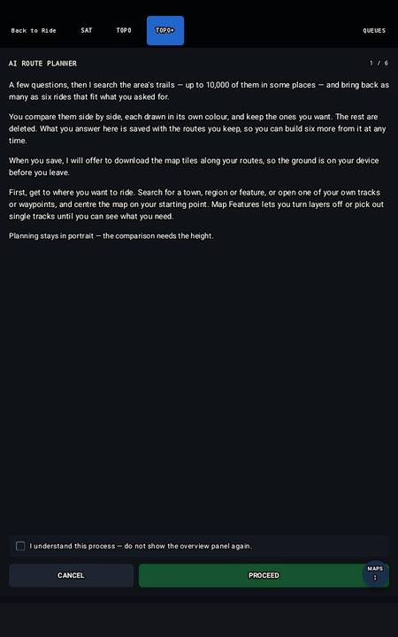

What the planner is about to do.

Six questions, then it searches the area's trails — **up to 10,000 of them in some places** — and brings back as many as six routes that fit what you asked for.

**What you answer is saved with the routes you keep**, so you can build six more from the same brief at any time.

Get to where you want to ride first. Search for a town, region or feature, or open one of your own tracks or waypoints, and centre the map on your starting point.

**Planning stays in portrait** — the comparison needs the height.

**CANCEL AI BUILD** is on every step before the build: it leaves the planner completely, removes this run's unfinished route, and takes you back to the map.

### 1 · How long a day?

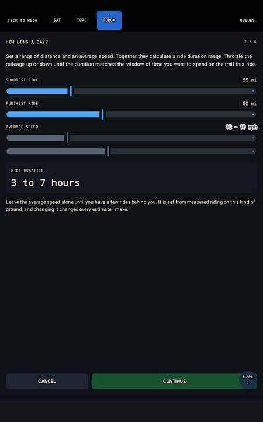

Distance and speed give you a duration.

Set the shortest and furthest you want to ride, and an average speed. Together they give a **ride duration**. Move the mileage until the hours match the time you have.

**Leave the average speed alone until you have a few rides behind you.** It is set from measured riding on this kind of ground, and changing it changes every estimate the planner makes.

### 2 · Where you will park

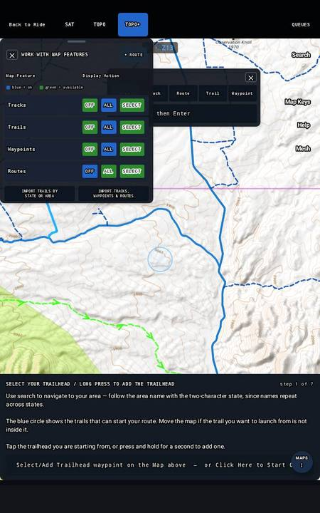

Tap a waypoint, or press and hold to make one.

Tap the waypoint where you will park. If there is none there, **press and hold for a second** to create one — creating it selects it, so you do not need to tap again.

Pick a spot that visibly reaches the trail network: several trails leaving in different directions, not a single dead-end spur.

**The trailhead must have a trail shown on the map within the half-mile circle** around it. If not, the planner says so and you choose again — check Map Keys: a trail type switched off there is not used for planning. Map Features no longer opens by itself at this step.

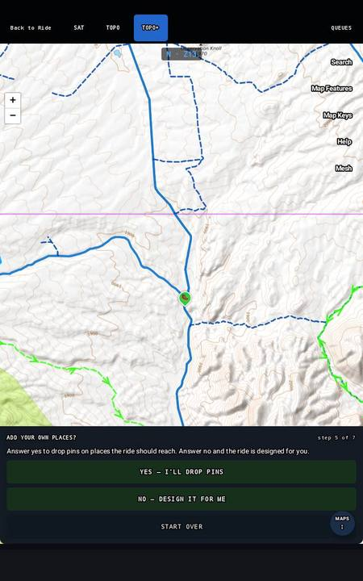

Places the ride should reach.

Optional. If there are places you want the ride to reach, tap the closest trail to each. Tap a pin again to remove it.

The planner includes as many as it can, **as long as it can find a route over existing trails to reach them**. One it cannot reach, or one that would push the ride past your distance, is refused with a reason rather than quietly ignored.

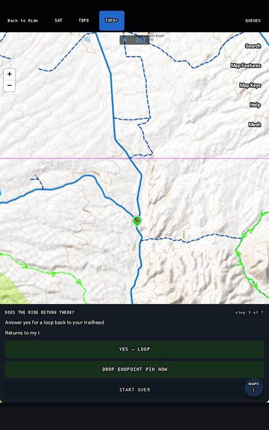

A loop, or somewhere else.

A loop back to where you started is what most day rides use. The other option is a different endpoint — a second trailhead, or somewhere you are staying.

### 5 · Review

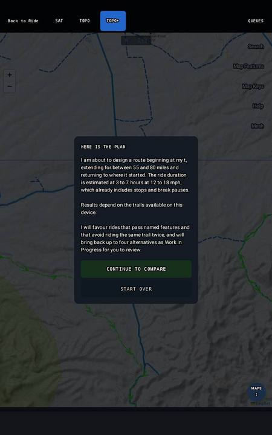

What it is about to build.

The planner reads back what it will do: where it starts, how far, how long, and at what pace.

[figure not shown]

Continue to compare.

### 6 · Compare

The compare table sits narrow over the map — up to six routes — so the routes underneath stay visible. **▾ Hide** folds it to its header; **▸ Expand** brings it back. The line under it says: *"Tap a ride name to show or hide its route."*

[figure not shown]

The routes, side by side.

Each route is drawn in its own colour and listed against the others — distance, riding time, and the trails each one uses. **Tap a route's name to take it off the display** while you look at the rest.

[figure not shown]

Tick the ones you want.

Keep what you want. **The rest are deleted.**

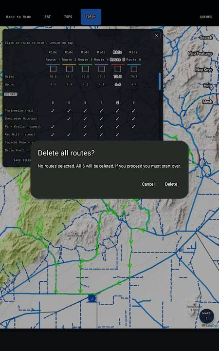

Nothing ticked means nothing kept.

[figure not shown]

And it offers the map tiles along them.

When you save, the planner offers to **download the map tiles along your routes**, so the ground is on your device before you leave.

**Next: make it a ride.** Tap a route you kept — its description opens — and tap **CREATE RIDE** (Creating a ride from a route).

Results depend on the trails on your device. Planning a route in a state you have not imported will return less than it should — import it first.

**4.6 H · Map Keyswhat the lines mean**

The same control as on the Ride Map — see the Ride Map, J · Map Keys.

**4.7 I · Helpthe three documents**

The same control as on the Ride Map — see the Ride Map, K · Help.

**4.8 J · GRP Awarenessyour radio in one place**

The same control as on the Ride Map — see the Ride Map, L · GRP Awareness.

**4.9 K · MAPSimagery for offline use**

Downloads the satellite and topo imagery so the map works with no signal. It is the one preparation that cannot be done at the trailhead.

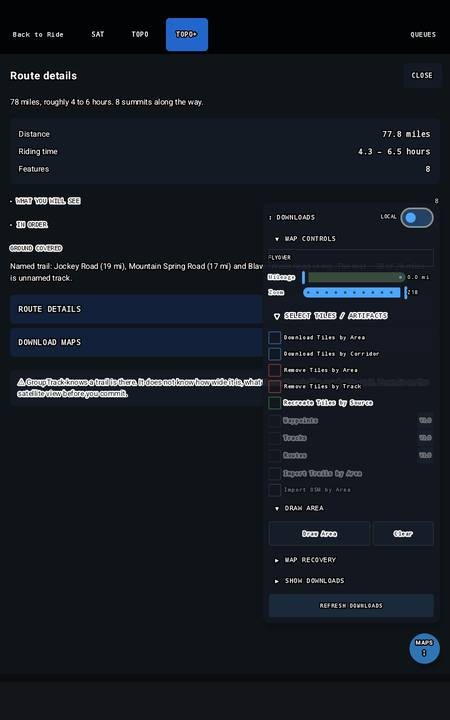

The download options.

**4.9.1 By areadraw a box**

[figure not shown]

Press Draw, drag a box, then Submit.

[figure not shown]

What it is about to fetch.

It tells you what the download amounts to before it starts.

**4.9.2 Along a routethe efficient one**

[figure not shown]

The route corridor.

Far more efficient than an area — a corridor follows the line and takes only the ground either side of it, rather than a box that is mostly ground you will never ride.

You can also start this from a route or track’s own popup.

**4.9.3 What you already haveblue is yours, red is coming**

[figure not shown]

Blue is downloaded. Red is queued.

Pan around before you leave and check the area you are riding is blue.

[figure not shown]

By source, and how many tiles at each level.

You can also see what you hold for each map source, level by level, and rebuild a source if you change it.

**4.10 L · Zoom + / −new in 2.7a**

Zoom in and out with the **+ / −** buttons, or pinch. The maps stop at the deepest zoom their tiles support.

**4.11 M · Tapping a feature on the maptap a route, track, trail or waypoint**

**Map touches are the simplest, fastest way to build a ride.** Tap a route or a track on the map, then tap the ride button — **CREATE RIDE** on a planner route or a track, **ADD A RIDE** on a route you drew — and the ride form opens with the route, its trailhead and its picture. Fast and easy. (★ Create a Ride)

**Everything you can do with a route, a track, a trail or a waypoint starts with one tap.** Tap it on the map, or find it with Map Features → SELECT, and its panel opens — a route the planner built opens its **description** when tapped, its detail panel from SELECT. **Routes and tracks are where rides are created** (★ Create a Ride, new in 2.7a); trails and waypoints have their own functions.

- **A route** → 4.5.2 Routes — ★ Create a Ride
- **A track** → 4.5.3 Tracks — ★ Create a Ride
- **A trail** → 4.5.4 Trails
- **A waypoint** → 4.5.5 Waypoints

These are documented once, in 4.5 Map Features. What every touch on the map does — taps, long press, pinch — is in 4.14 Map gestures.

On the Ride Map the same taps open the same panels, without ride creation.

**4.12 N · Work with Ridesrides — share, edit, delete; import; apply to your radio**

The same control as on the Ride Map — see the Ride Map, U · Work with Rides.

**4.13 O · Long press — add a waypointnew in 2.7a**

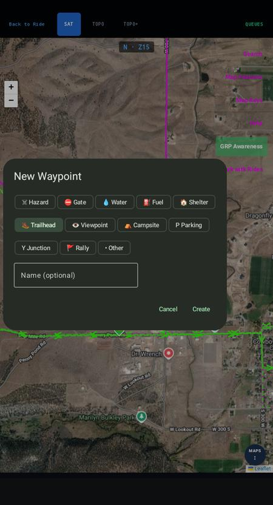

New Waypoint — a long press on open map.

**Long press on open map** and New Waypoint opens, already set to **Trailhead**. Pick a type, give it a name if you like, and tap **Create**. Left blank, the name follows the type. Choosing **Other** asks once — *Save as Other?* — so a waypoint is never filed as Other by accident.

To change a waypoint later, tap it: its detail panel offers **RENAME**, **CHANGE TYPE**, **DELETE** and **FIT**. A route's trailhead cannot be retyped or deleted while the route uses it — remove the route first.

**4.14 Map gestureswhat a touch on the map does**

**Map touches are the simplest, fastest way to build a ride.** Tap a route or a track on the map, then tap the ride button — **CREATE RIDE** on a planner route or a track, **ADD A RIDE** on a route you drew — and the ride form opens with the route, its trailhead and its picture. Fast and easy. (★ Create a Ride)

Two kinds of touch work the planning map. **Moving it** is the map's own gesture. **Touching a feature** opens that feature's screens — the same screens as Map Features → SELECT, so their pictures are shown there.

### Moving the map

- **Pan:** drag in any direction — left, right, up, down.
- **Zoom in and out:** pinch, or the **+ / −** buttons (L · Zoom).

### Creating a waypoint

**Long press on open map** — New Waypoint opens, starting as a **Trailhead**; choosing Other asks once. (Long press — add a waypoint)

### Touching a feature

| Touch | What opens | What you can do there | Recipes |
| --- | --- | --- | --- |
| **a route** | **While a route is being drawn:** nothing — the tap places a point. **A route the planner built:** its **description** — the only way to reach it. **Otherwise:** the **detail panel**. | description: **ROUTE DETAILS · CREATE RIDE · DOWNLOAD MAPS** detail panel: RENAME · DELETE · SHARE · EXPORT · OVERVIEW · **ADD A RIDE** · BUILD ROUTES FROM RECIPE (planner routes) · SAVE MAPS · FIT | Creating a ride from a route |
| **a track** | the **detail panel** (track) | RENAME · DELETE · SHARE · EXPORT · **CREATE RIDE** · SAVE MAPS · FIT | Creating a ride from a track |
| **a waypoint** | the **detail panel** (waypoint) | RENAME · DELETE · **CHANGE TYPE** · FIT | A waypoint |
| **a trail** | the **detail panel** (trail) | SHARE · EXPORT · FIT (and DELETE, on a rider trail you made) | Tapping a feature on the map |

**5 The Ride Mapwhat you use on the trail**

The map you use in the field. Every control on it is lettered on the picture below. Each letter has a heading underneath, and each heading opens. Open one and you get that control in full — the screens it leads to, in the order you meet them, and what to do at each.

It is arranged this way so you can focus on the one thing you are trying to do, without everything around it competing for your attention. Find your letter, open that heading, and the rest of the manual stays out of the way.

[figure not shown]

Ride Map — every control lettered; tap a letter to go to it

1. A**CHK IN › REC** — check in, then record — with no radio, REC records on its own 5.1
2. B**Ride Planning** — switches to the planning map 5.2
3. C**SAT** — the map underneath 5.3
4. D**TOPO** — the map underneath 5.3
5. E**TOPO+** — the map underneath 5.3
6. F**NET and LOCAL** — internet, or only what is on the device 5.4
7. G**QUEUES** — downloads in the background 5.5
8. H**Search** — reposition the map, by name 5.6
9. I**Map Features** — trails, tracks, routes, waypoints 5.7
10. J**Map Keys** — what the lines mean 5.8
11. K**Help** — the three documents 5.9
12. L**GRP Awareness** — your radio in one place 5.10
13. M**Settings** — preferences, and your release level 5.11
14. N**HIDE** — unclutter the map 5.12
15. O**VIEW CART ROLES** — the carts on your ride: who is checked in, remove, activate, change my role 5.13
16. P**MY CART** — back to you, and follows you 5.14
17. Q**GROUP** — a wider view, or the whole group 5.15
18. R**The readout** — the group at a glance, or your own cart 5.15
19. S**Zoom** — in and out — or pinch 5.16
20. T**GPS** — how often your location is sent 5.17
21. U**Work with Rides** — rides — share, edit, delete; import; apply to your radio 5.18
22. V**Distance** — miles recorded on this ride — shown while recording not on the picture 5.19
23. W**Tapping a feature on the map** — trails, tracks, routes and waypoints open their details not on the picture 5.20
24. X**Long press — add a waypoint** — the new waypoint starts as a Trailhead not on the picture 5.21

**5.1 A · CHK IN › RECcheck in, then record your track**

With a radio connected, the button first reads **✔ CHK IN › REC** — check in to your ride, then tap **⏺ REC**. See Checking in and recording your track.

Press the red button to start. Do it **before you set off** — the first part of a ride is usually the part you most want on the map afterwards.

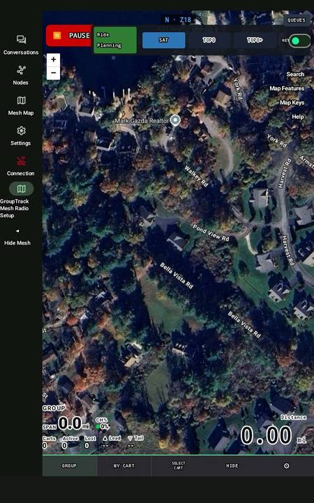

Recording has started.

### Riding with a group

If you are riding with a mesh group you are asked to **pick the lead cart**. That cart lays down a track which is visible on every device in the group — so everyone behind can follow the line the leader actually took.

Once riders have checked in, **the Leader role decides the lead** — roles change at a stop, from **VIEW CART ROLES**.

### What you will see

Keep the screen where you can see it. Riding alone, your cart sits in the centre with your track behind you and the ground ahead.

In a group you also see the **lead cart's track laid out ahead of you**, and a pin for every other cart.

### If you stop for a while

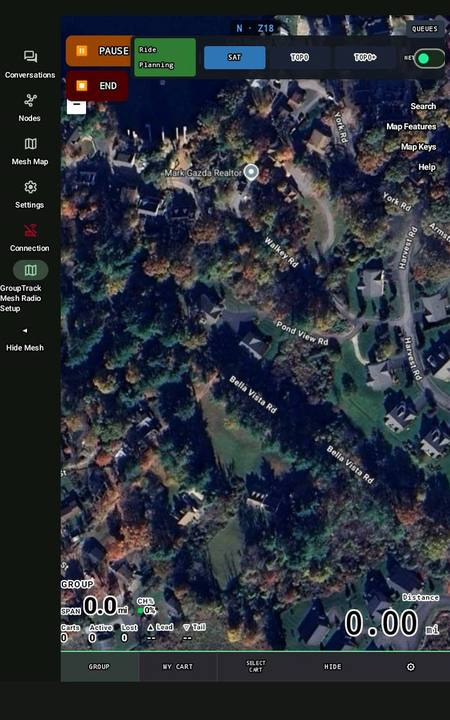

Paused.

GroupTrack notices when you have not moved for a time and **pauses recording itself**, closing the connection to your radio as it does.

That is deliberate. A T1000-E that times out on its own has a hard time reconnecting; ending the session from this end is clean, and it reconnects without trouble when you resume.

You come back to a **flashing red banner**. Tap it to carry on — the radio reconnects and the recording continues into the same track.

**While it is paused, your radio is disconnected** — not just the recording. The group stops hearing you, and your map stops showing them, until you tap the banner.

### Ending the ride

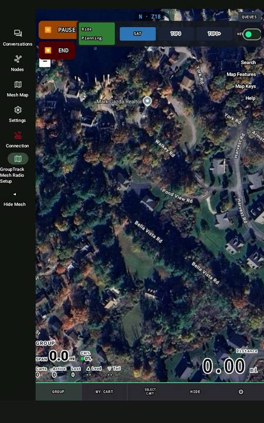

Press END.

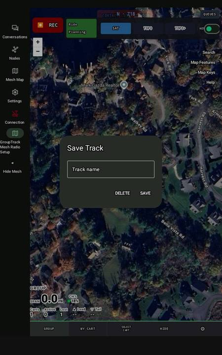

Name it, or delete it.

1. Give the ride a name you will recognise later. The date is kept for you.
2. **Save** keeps it — it appears on the map and in your tracks.
3. **Delete** throws it away. There is no undo.

Recording uses GPS the whole time. On a long day, bring a charger.

**5.1.1 Check in, then recordnew in 2.7a**

**With a radio,** CHK IN opens the check-in — pick the ride and your role, and your radio is set up for that ride — then the button becomes **REC**. **With no radio,** REC records a solo ride straight away. **END** saves the ride (the Save your ride form) and sets every cart back to Active.

**5.2 B · Ride Planningswitches to the planning map**

Switches to the Ride Planning map, where everything you do before a ride happens. **Back to Ride** in its top-left corner brings you back.

**5.3 C, D, E · SAT, TOPO and TOPO+the map underneath**

Three slots, each holding a map source you chose. Tap one and the map redraws in that source. What is drawn on top does not change.

[figure not shown]

SAT.

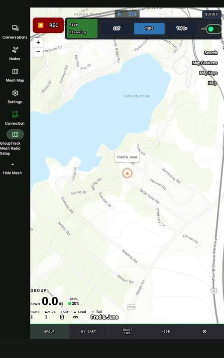

TOPO.

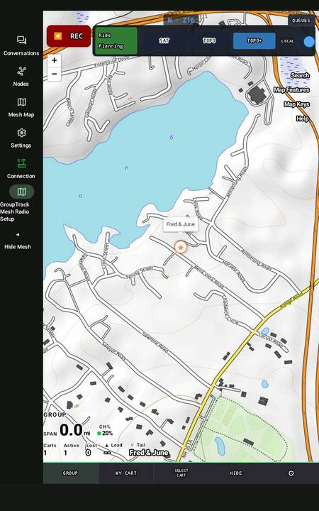

TOPO+.

Which source sits in which slot is yours to choose, in Settings. Out of the box, **TOPO+ holds OpenTopoMap**.

**5.4 F · NET and LOCALinternet, or only what is on the device**

A toggle. **NET** uses internet map sources. **LOCAL** uses only what is already downloaded to the device.

[figure not shown]

NET.

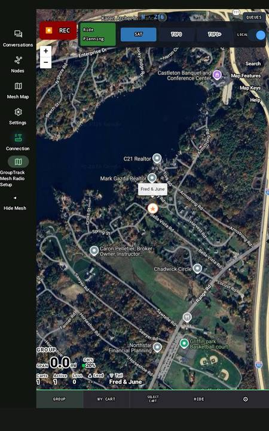

LOCAL.

**Use NET for ride planning**, where you want everything available.

**Switch to LOCAL before you leave** and pan around the area you are riding. What you can see is what you will have on the trail. Anything blank is ground you will have no map for.

This is the reason for downloading maps. Off grid, a source you did not download gives you nothing.

**5.5 G · QUEUESdownloads in the background**

Map downloads run in the background so they do not tie up the screen.

[figure not shown]

Running.

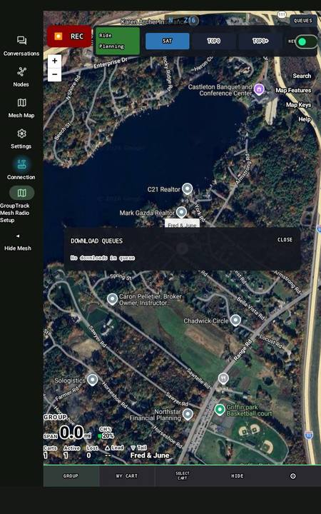

Nothing queued.

Leave the screen and carry on — the download continues. **If the device is turned off it picks up where it stopped** rather than starting again.

### Managing the queue

- A job can be **held**, **cancelled**, or **purged** once complete.
- Anything waiting can be **promoted to run next**.

### What runs first

The queue sorts itself so the work you need soonest happens soonest.

1. **Tile deletions** — freeing space before filling it.
2. **Anything you promoted.**
3. **Corridor downloads** — a route's tiles.
4. **Area downloads** — a bounding box.
5. **Map source refreshes** — last, and they wait.

**A large refresh never blocks you.** Ask for an area or a corridor while one is running and yours goes ahead of it; the big job carries on afterwards.

There is a limit on how many downloads run at once. It is already tuned — worth leaving alone.

**5.6 H · Searchreposition the map, by name**

Search repositions the map so what you searched for is **centred**. It is what lets you plan a ride anywhere in the country from your living room.

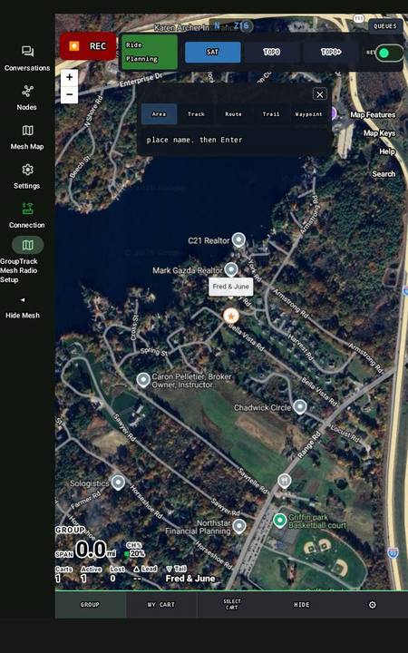

The search bar.

### Finding one of your own

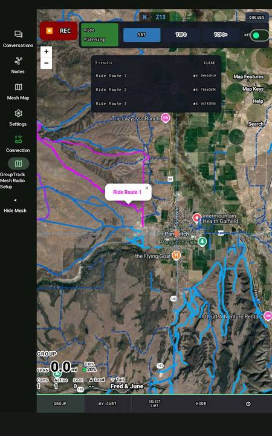

Matches.

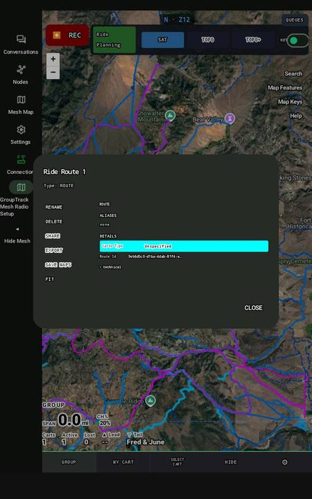

Tap the name you want.

Searching for a track, route or waypoint produces a list. Tap the name of the one you want and the map moves to it.